# In Any Case: Homeless in America

An analysis of the homeless population focused on the cities of Atlanta, Orlando, Florida and Cleveland

# Data

The data used for this US homelss population study was provided by the US Housing and Urban Development office as a public record. The following information used in this study can be found at the link provided: https://www.hudexchange.info/resource/5639/2017-ahar-part-1-pit-estimates-of-homelessness-in-the-us/

The data collected during this study is categorized as a point-in-time estimate. Meaning the data was collected during a definitive period of time. Specifically during the last two weeks of January, all public continuums of care or CoC. Continuums of care are public foundations that focus on asissting homeless in need by providing food, shelter and other necessary resources.

# Total homeless in the US from 2007 - 2017

The plot shows the trend of homelessness in the US is a negative trend overall. The Obama administration began a public program, Opening Doors’ in 2010 to address the homeless issue and decrease the amount of homeless in the country. As shown in the figure, the homeless population has been on a consistent negative trend since the year of the programs beginning with 2016-2017 being the first upward slope.

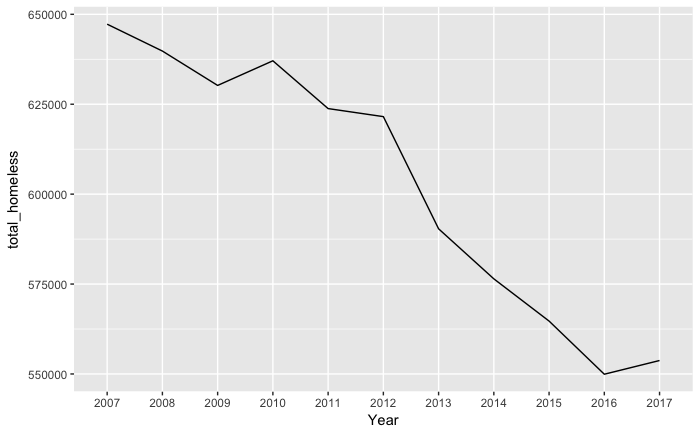

```r
homeless_per_year <- ddply(df.CoC_Cleaned, "Year", summarise, total_homeless = sum(as.numeric(Total.Homeless)))
ggplot(homeless_per_year, aes(Year, total_homeless, group = 1)) +
  geom_line()
```

# Get the 4 cities to observe: Orlando, Seattle, Atlanta, Cleveland and their total homeless figures

The cities selected for a detailed discuss in the ‘2 Cents on Homelessness’ podcast are Orlando, Seattle and Atlanta. I decided to add my home city, Cleveland, to understand how it compared to the other cities in this analysis. The cordinal points (longitude and latitude) for each city was not provided in the initial HUD data but was necessary to provide the geographical visual. The R script library “ggmap” was used to query each city’s longitude and laitutde location to plot on the US map with the proper ‘Total.Homeless’ value for each respsective city. Seattle has more homeless at 11,643 than the other three cities combined. The plot not only shows the geographical location of each city but a visual of how each homeless population compares with a varied dot indicator (a larger homeless population equals a larger dot).

[figure not shown]

# 4 City Analysis

When observing the ‘Total.Homeless’ population amoungst the four selected cities, the trend is not directly similar to the rest of the US. The total US homeless expersience is decline beginning the same year as the Obama administrations Opening Door program. The 4 city (OASC) homeless population did not experience a decline until the following year of Opening Door’s birth. Unlike the US population, the OASC population experienced two upward trends in 2014 and 2016. The categorized bar and line charts show how this total population is sectioned amongst the various cities. This shows Seattle has been experiencing a near consistent increase in their homeless population since 2007 with a significant spike from 2014 -2017. The three additional cities have been able to decrease their current (2017) homeless population when comparing the beginning of the data collection (2007).

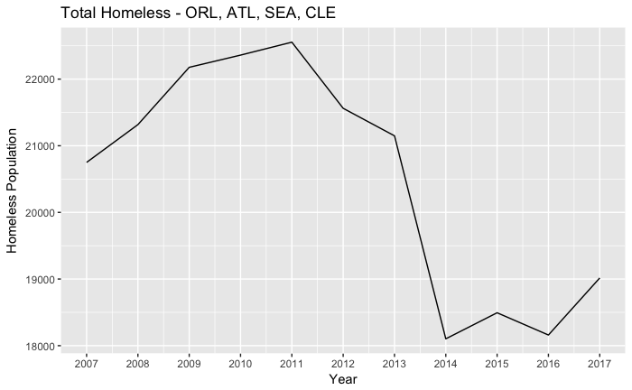

```r
ggplot() +
  geom_line(data = df.OAS_total_homeless, aes(x = as.numeric(Year), y = total_homeless_OAS)) +
  geom_text(label = df.OAS_total_homeless$total_homeless_OAS) +
  scale_x_continuous(breaks = seq(2007, 2017)) +
  ggtitle("Total Homeless - ORL, ATL, SEA, CLE") +
  xlab("Year") +
  ylab("Homeless Population")
```

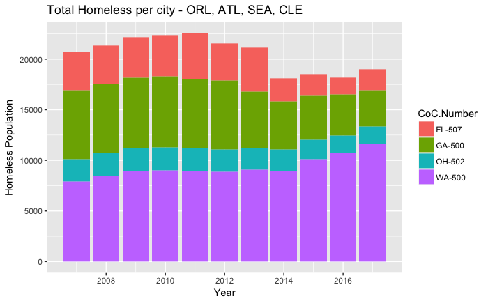

```r
ggplot(data = df.OAS, aes(x = as.numeric(Year), y = as.numeric(Total.Homeless))) +
  geom_bar(aes(fill = CoC.Number), stat = "identity") +
  ggtitle("Total Homeless per city - ORL, ATL, SEA, CLE") +
  xlab("Year") +
  ylab("Homeless Population")
```

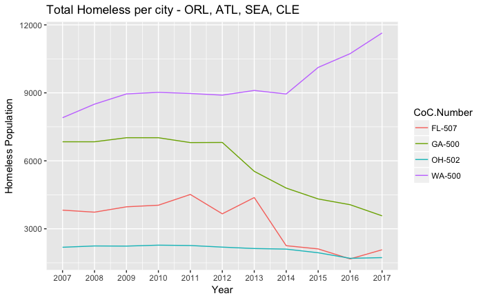

```r
ggplot(df.OAS, aes(as.numeric(Year), as.numeric(Total.Homeless), color = CoC.Number)) +
  geom_line() +
  scale_x_continuous(breaks = seq(2007, 2017)) +
  ggtitle("Total Homeless per city - ORL, ATL, SEA, CLE") +
  xlab("Year") +
  ylab("Homeless Population")
```

# Sheltered vs. Unsheltered Homeless Population

Part of HUDs data collection is to track the amount of homeless that are within shelters for the night and those that were found outside during the night. The following analysis is solely for 2017 amongst the four cities. Every city, besides Seattle, show is significant difference between the amount of sheltered versus unsheltered. Similar to the total homeless analysis, Seattle does not follow a trend of the other three cities. The city of Seattle shows the amount of unsheltered are nearly as equal to the amount of sheltered homeless. The avaerage weather in Seattle during the month of January is a high of 47 degrees F and a low of 37 degrees F. There has been a number of tent cities developed on the west coast of the US and this may explain the near similairty in Seattle for sheltered versus unsheltered.

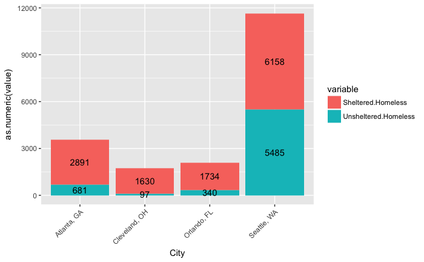

# Homeless Youth

Another imperative topic discussed during the podcast is the homeless youth population. As noted from our guest speaker, David’s dad, “the amount of homeless youth out here is getting scary. I always ask ‘Where are your parents?’ and they have no one close to take them in”. According to HUD, a homeless youth is categorized as an unassisted youth under the afe of 25. As expected, Seattle does not follow the trend of the other three cities. The amount of unsheltered homeless youth in the city is more than three times greater than the sheltered homeless youth.

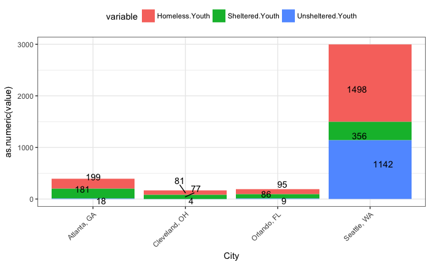